# Reproducible Research Peer-graded Assignment: Course Project 1

## Imputing missing values

###### 1.Calculate and report the total number of missing values in the dataset (i.e. the total number of rows with NAs)

```r
TNRWNA <- nrow(subset(activitydata, is.na(activitydata$steps)))
```

Number of missing values: 2304

###### 1.Create a new dataset that is equal to the original dataset but with the missing data filled in.

```r
Imputed_Data <- activitydata
Imputed_Data$steps <- impute(activitydata$steps, fun=mean)
```

###### 2.Devise a strategy for filling in all of the missing values in the dataset.

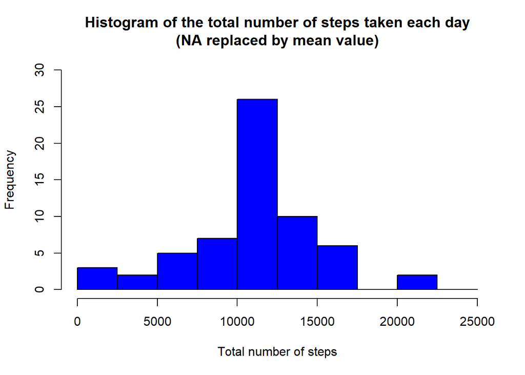

```r
stepsByDayImputed <- tapply(Imputed_Data$steps, Imputed_Data$date, sum)

hist(stepsByDayImputed,
     breaks=seq(from=0, to=25000, by=2500),
     col="blue",
     xlab="Total number of steps",
     ylim=c(0, 30),
     main="Histogram of the total number of steps taken each day\n(NA replaced by mean value)")
```

```r
stepsByDayMeanImputed <- mean(stepsByDayImputed)
stepsByDayMedianImputed <- median(stepsByDayImputed)
```

## Are there differences in activity patterns between weekdays and weekends?

###### 1.Create a new factor variable in the dataset with two levels - “weekday” and “weekend” indicating whether a given date is a weekday or weekend day.

```r
weekdays <- c("Monday", "Tuesday", "Wednesday", "Thursday",
              "Friday")
Imputed_Data$dow = as.factor(ifelse(is.element(weekdays(as.Date(Imputed_Data$date)),weekdays), "Weekday", "Weekend"))
```

###### 2.Make a panel plot containing a time series plot (i.e. type = “l”) of the 5-minute interval (x-axis) and the average number of steps taken, averaged across all weekday days or weekend days (y-axis). See the README file in the GitHub repository to see an example of what this plot should look like using simulated data.

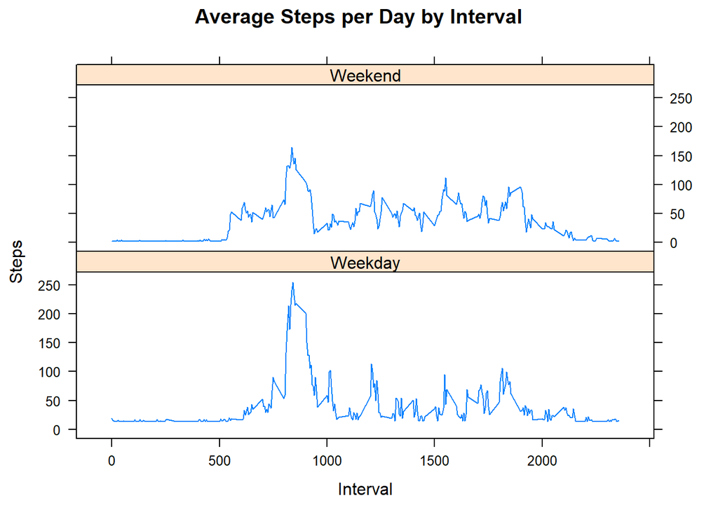

```r
StepsByInterval <- aggregate(steps ~ interval + dow, Imputed_Data, mean)

xyplot(StepsByInterval$steps ~ StepsByInterval$interval|StepsByInterval$dow, main="Average Steps per Day by Interval",xlab="Interval", ylab="Steps",layout=c(1,2), type="l")
```